# Dealing with Heterogeneity

## Find the best variance structure.

Here you will start your modelling exercise based on the premise that variance heterogeneity is interesting ecological information. *Because it is statistically inconvenient, you should not throw away this information*. The question now is, *how to incorporate this heterogeneity?* For this, you will use multiple mathematical parametrisations to explain the observed variance structure given the predictors.

But remember that we cannot compare an `lm` object to a `gls` object (the one we will use to model the variance). Therefore you need to build the linear regression model again with the `gls()` function.

**Your task:**

Build the linear regression model again with the `gls()` function.

For this, you will need to download and install the Linear and Nonlinear Mixed Effects Models (`nlme`) package (`install.packages("nlme", dependencies=TRUE))`), and then load it (`library(nlme)`)].*

```r
# Load the nlme package
library(nlme)

# Apply the linear regression model again with the gls command
gls.ieno <- gls(Concentration ~ Biomass * Treatment * Nutrient, # The regression object
  data = ieno
) # The object with the data
gls.ieno
```

```
## Generalized least squares fit by REML
##   Model: Concentration ~ Biomass * Treatment * Nutrient
##   Data: ieno
##   Log-restricted-likelihood: -254.2602
##
## Coefficients:
##                          (Intercept)                              Biomass
##                           13.7327222                            2.0486667
##                     TreatmentNoAlgae                          NutrientNO3
##                          -13.2496944                          -13.6260556
##                          NutrientPO3             Biomass:TreatmentNoAlgae
##                          -11.4989133                           -1.4479333
##                  Biomass:NutrientNO3                  Biomass:NutrientPO3
##                           -2.0436667                           -1.8624533
##         TreatmentNoAlgae:NutrientNO3         TreatmentNoAlgae:NutrientPO3
##                           16.0223611                           11.4301011
## Biomass:TreatmentNoAlgae:NutrientNO3 Biomass:TreatmentNoAlgae:NutrientPO3
##                            0.8469333                            1.5228267
##
## Degrees of freedom: 108 total; 96 residual
## Residual standard error: 2.933848
```

With this initial model ready, you are prepared to build a series of models describing the residual variance as a function of `Biomass`, `Treatment`, and/or `Nutrient`.

**Your task:**

Build a series of models where you describe the residual variance as:

- One variance term per `Nutrient`.
- One variance term per `Treatment`.
- One variance term per `Nutrient`–`Treatment` combination.

All models should have main terms, two-way interactions, and the three-way interaction term as a fixed component.

The residual variance will be model as a function of the categorical predictors using the `varIdent()` function.

```r
# Model 1: The variance changes between `Nutrient`.
gls.Nut.ieno <- gls(Concentration ~ Biomass * Treatment * Nutrient, # The regression object
  data = ieno, # The object with the data
  weights = varIdent(form = ~ 1 | Nutrient)
)

# Model 2: The variance changes between `Treatment`s.
gls.Tre.ieno <- gls(Concentration ~ Biomass * Treatment * Nutrient, # The regression object
  data = ieno, # The object with the data
  weights = varIdent(form = ~ 1 | Treatment)
)

# Model 3: The variance changes between `Treatment` and `Nutrient`.
gls.NutTre.ieno <- gls(Concentration ~ Biomass * Treatment * Nutrient, # The regression object
  data = ieno, # The object with the data
  weights = varIdent(form = ~ 1 | Treatment * Nutrient)
)
```

With this, you now have all the components to assess which way to model the residual variance fits the data batter. *but how to do this?* the answer is the same way you compare linear models with a Gaussian (normal) distribution: **Log-likelihood ratio tests**.

**Your task:**

Use the `anova()` function to contrast the first linear regression model without any variance covariates (`gls.ieno`) to the models that model the residual variance as:

- One variance term per `Nutrient`–`Treatment` combination.
- One variance term per `Nutrient`.
- One variance term per `Treatment`.

```r
# Assess the fit of Model 1:
anova(
  gls.ieno, # the first model
  gls.Nut.ieno # the `Nutrient`. model
)
```

```
##              Model df      AIC      BIC    logLik   Test  L.Ratio p-value
## gls.ieno         1 13 534.5203 567.8569 -254.2602
## gls.Nut.ieno     2 15 380.0830 418.5482 -175.0415 1 vs 2 158.4374  <.0001
```

```r
# Is this model better than the first model?
## YES!! Based on the Log-likelihood ratio test, the `Nutrient` model is better than one without a variance structure! [the test is significant and has lowed AIC]

# Assess the fit of Model 2:
anova(
  gls.ieno, # the first model
  gls.Tre.ieno # the `Treatment`. model
)
```

```
##              Model df      AIC      BIC    logLik   Test  L.Ratio p-value
## gls.ieno         1 13 534.5203 567.8569 -254.2602
## gls.Tre.ieno     2 14 439.7639 475.6647 -205.8819 1 vs 2 96.75648  <.0001
```

```r
# Is this model better than the first model?
## YES!! Based on the Log-likelihood ratio test, the `Treatment` model is better than one without a variance structure! [the test is significant and has lowed AIC]


# Assess the fit of Model 3:
anova(
  gls.ieno, # the first model
  gls.NutTre.ieno # the `Treatment` and `Nutrient`. model
)
```

```
##                 Model df      AIC      BIC    logLik   Test  L.Ratio p-value
## gls.ieno            1 13 534.5203 567.8569 -254.2602
## gls.NutTre.ieno     2 18 330.1298 376.2881 -147.0649 1 vs 2 214.3905  <.0001
```

```r
# Is this model better than the first model?
## YES!! Based on the Log-likelihood ratio test, the `Treatment` and `Nutrient` model is better than one without a variance structure! [the test is significant and has lowed AIC]
```

Based on the results above, you see that including a description of the residual variance results in a better model. Now the question is, which is the best variance structure?.

**Your task:**

Use the function `anova` to contrast the linear regression models that describe the residual variance. Do this in this sequence:

- Contrast the one variance term per `Nutrient` model to the one variance term per `Treatment` model.
- Contrast the best of the two models above to the `Nutrient`–`Treatment` combination model.

```r
# Contrast the per `Nutrient` model vs. per `Treatment` model.
anova(
  gls.Nut.ieno, # the `Nutrient`. model
  gls.Tre.ieno # the `Treatment`. model
)
```

```
##              Model df      AIC      BIC    logLik   Test  L.Ratio p-value
## gls.Nut.ieno     1 15 380.0830 418.5482 -175.0415
## gls.Tre.ieno     2 14 439.7639 475.6647 -205.8819 1 vs 2 61.68087  <.0001
```

```r
# Which is the best model?
## based on the Log-likelihood ratio test, the `Nutrient` model is better than the `Treatment`s model [the test is significant and has lowed AIC]

# Contrast the per `Nutrient`/`Treatment` model vs. the `Nutrient`&`Treatment` model
anova(
  gls.Nut.ieno, # the `Nutrient`. model
  gls.NutTre.ieno # the `Treatment` and `Nutrient`. model
)
```

```
##                 Model df      AIC      BIC    logLik   Test L.Ratio p-value
## gls.Nut.ieno        1 15 380.0830 418.5482 -175.0415
## gls.NutTre.ieno     2 18 330.1298 376.2881 -147.0649 1 vs 2 55.9532  <.0001
```

```r
# Which is the best model?
## based on the Log-likelihood ratio test, the `Treatment` and `Nutrient` model is better than the `Nutrient` alone model [the test is significant and has lowed AIC]
```

The comparisons above show that the model with the lowest (=best) AIC is one where residual variances can vary by `Treatment` and `Nutrient`.

*How would you describe that your model needs to allow the residual variances to vary by `Treatment` and `Nutrient` in a scientific paper?*. You would say that a variance structure that controls for both changes among nutrients and algal enrichment is considerably better than the constant variance in the linear regression model (L=214.4, *P*<0.0001).

## Is all this effort worth it?

By now, you have invested quite some time figuring out the best way to model the residual variance so that the model does not have heterogeneity in the residuals. *but have you succeeded?*

**Your task:**

Test if we still have heterogeneity in the residuals. For this:

- Plot the normalised residuals against the fitted values.
- Plot the normalised residuals against each of the predictors.
- Is there homogeneity of variances now?

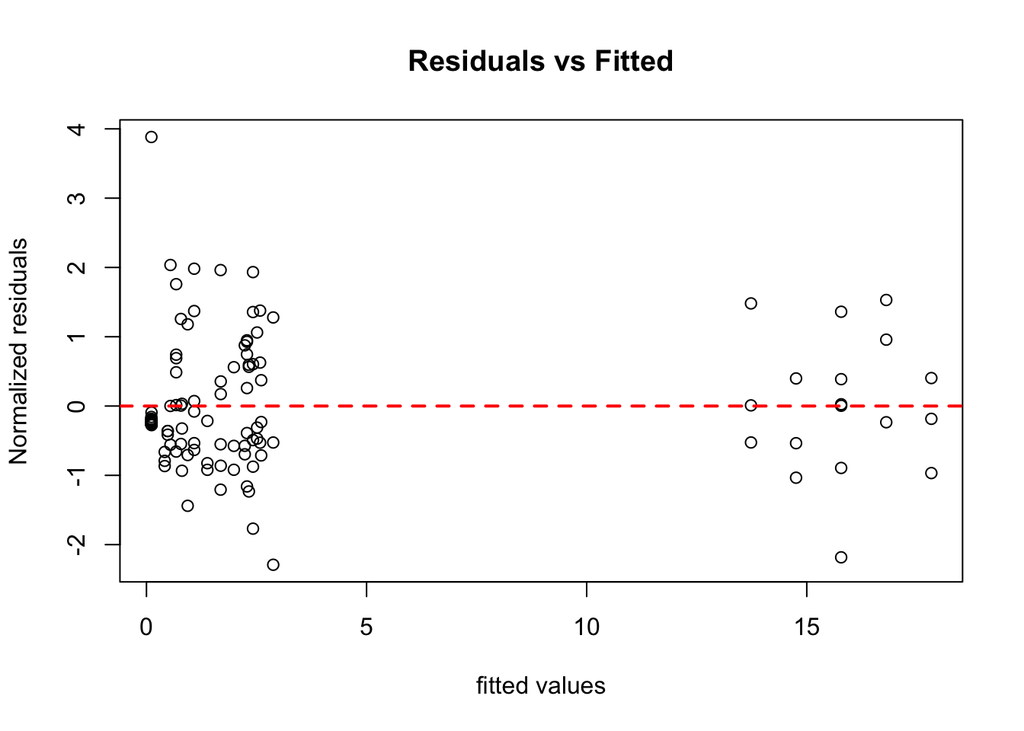

```r
# Extract the the normalised residuals using the `residuals()` function and the `type="normalised"` argument. (see ?residuals.gls to read the difference between residual types)
gls.NutTre.NorRes <- resid(gls.NutTre.ieno, # model to extract the residuals from
  type = "normalized"
) # type of residuals?

# Plot the normalised residuals against the fitted values.
plot(
  y = gls.NutTre.NorRes, # Normalised residuals
  x = fitted(gls.NutTre.ieno), # Extract the fitted value form the best model
  main = "Residuals vs Fitted", # figure title
  ylab = "Normalized residuals", # y-label text
  xlab = "fitted values"
) # x-label text
# add a horizontal line at zero
abline(
  h = 0, # location of the line
  lty = 2, # Line type
  lwd = 2, # Line width
  col = "red" # line colour
)
```

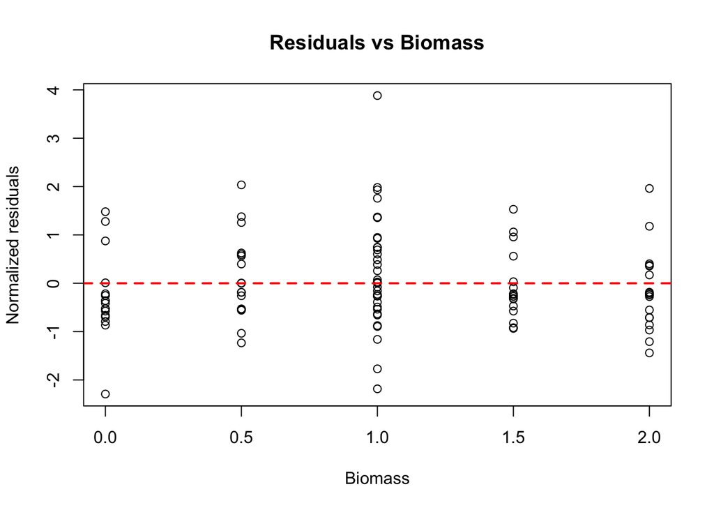

```r
# Plot the normalised residuals against the Biomass.
plot(
  y = gls.NutTre.NorRes, # Normalised residuals
  x = ieno$Biomass, # Extract the fitted value form the best model
  main = "Residuals vs Biomass", # figure title
  ylab = "Normalized residuals", # y-label text
  xlab = "Biomass"
) # x-label text
# add a horizontal line at zero
abline(
  h = 0, # location of the line
  lty = 2, # Line type
  lwd = 2, # Line width
  col = "red" # line colour
)
```

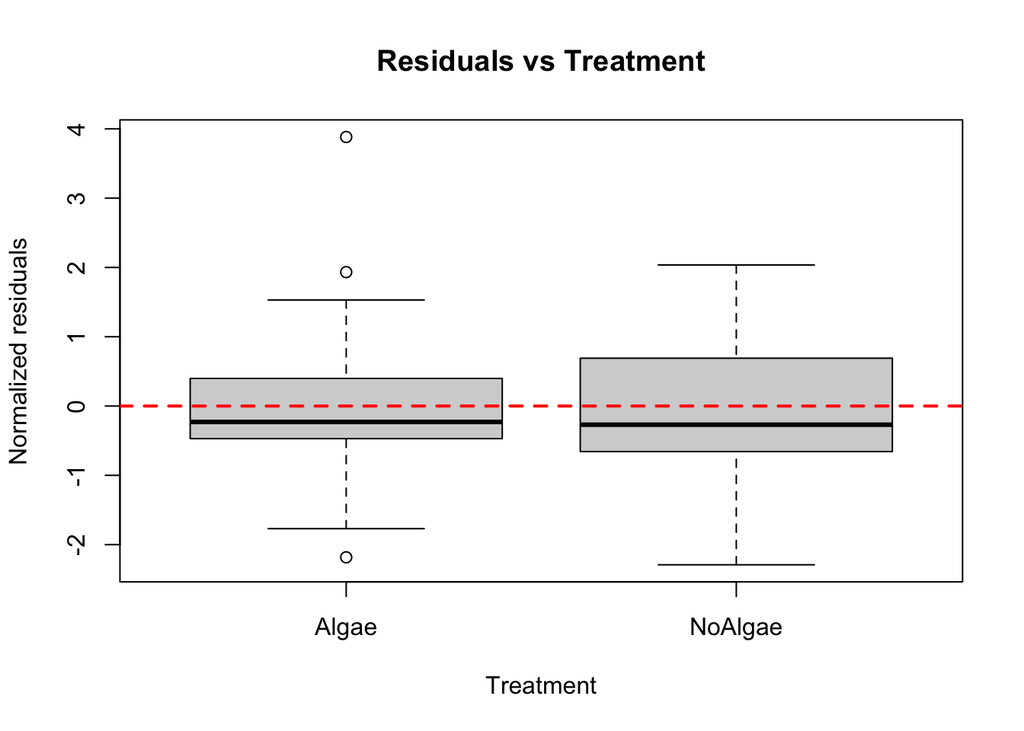

```r
# Plot the normalised residuals against the Treatment
boxplot(gls.NutTre.NorRes ~ # Normalised residuals
ieno$Treatment, # Extract the fitted value form the best model
main = "Residuals vs Treatment", # figure title
ylab = "Normalized residuals", # y-label text
xlab = "Treatment"
) # x-label text
# add a horizontal line at zero
abline(
  h = 0, # location of the line
  lty = 2, # Line type
  lwd = 2, # Line width
  col = "red" # line colour
)
```

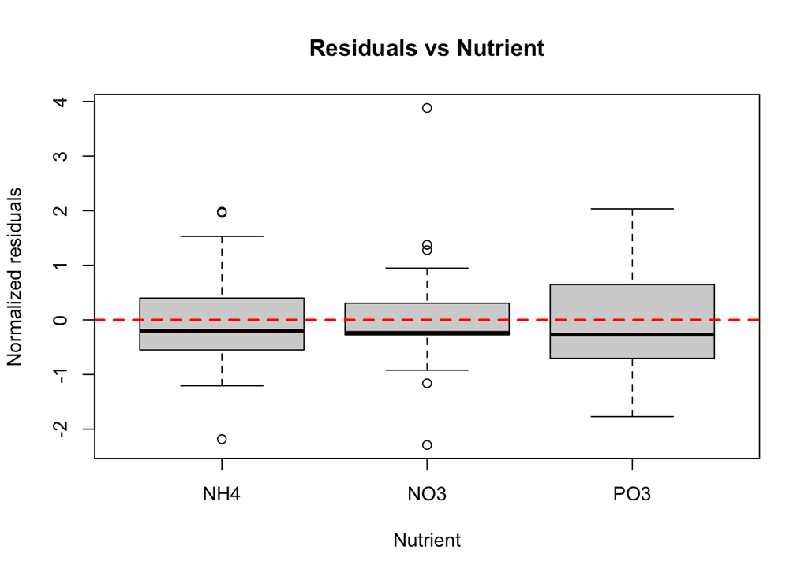

```r
# Plot the normalised residuals against the Nutrient
boxplot(gls.NutTre.NorRes ~ # Normalised residuals
ieno$Nutrient, # Extract the fitted value form the best model
main = "Residuals vs Nutrient", # figure title
ylab = "Normalized residuals", # y-label text
xlab = "Nutrient"
) # x-label text
# add a horizontal line at zero
abline(
  h = 0, # location of the line
  lty = 2, # Line type
  lwd = 2, # Line width
  col = "red" # line colour
)
```

```r
# Is there homogeneity of variances now?
## Comparing the plots above to `plot(gls.ieno)`, it is clear that the residuals are more homogeneous now.
```